# Environmental analysis using satellite image time series in R

Ewa Grabska-Szwagrzyk

## Part 1: Pre-processing and smoothing satellite image time series

### Loading and pre-processing data

Load the packages:

```r
if (!require("pacman")) install.packages("pacman")
pacman::p_load("tidyverse", "tsibble", "bfast", "data.table", "mgcv","forecast", "zoo", "anytime", "fabletools", "signal", "fable", "tibble")
```

Import data - raw MTCI values from Sentinel-2 acquired from GEE:

```r
df = read.csv("d:/OGH2023_data/species_mtci.csv")
str(df)
```

```
## 'data.frame':    1446996 obs. of  3 variables:
##  $ system.index: chr  "20170329T095021_20170329T095024_T33UXR_00000000000000000042" "20170329T095021_20170329T095024_T33UXR_00000000000000000043" "20170329T095021_20170329T095024_T33UXR_00000000000000000044" "20170329T095021_20170329T095024_T33UXR_00000000000000000045" ...
##  $ MTCI        : num  NA NA NA NA NA NA NA NA NA NA ...
##  $ species_cd  : chr  "GB" "GB" "GB" "GB" ...
```

```r
summary(df)
```

```
##  system.index            MTCI          species_cd
##  Length:1446996     Min.   :-8.2      Length:1446996
##  Class :character   1st Qu.: 1.3      Class :character
##  Mode  :character   Median : 3.1      Mode  :character
##                     Mean   : 3.0
##                     3rd Qu.: 4.4
##                     Max.   :17.8
##                     NA's   :1430563
```

As you can see, there is a lot of NA values, also, if we plot index values there are a lot of outliers.

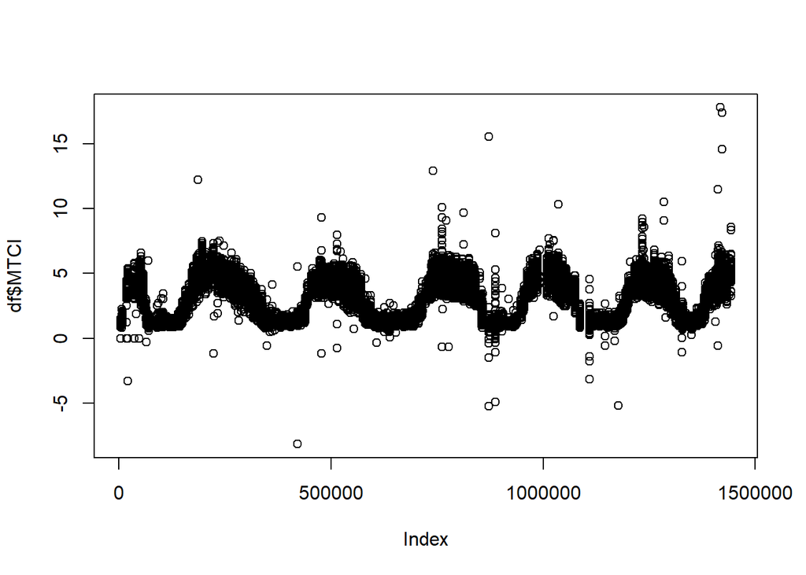

```r
plot(df$MTCI)
```

Modify column with date and change columns names:

```r
df$system.index = as.Date(df$system.index, format =  "%Y%m%d")
names(df) = c("date", "index", "type")
```

Filtering values, removing NA, mean of duplicates:

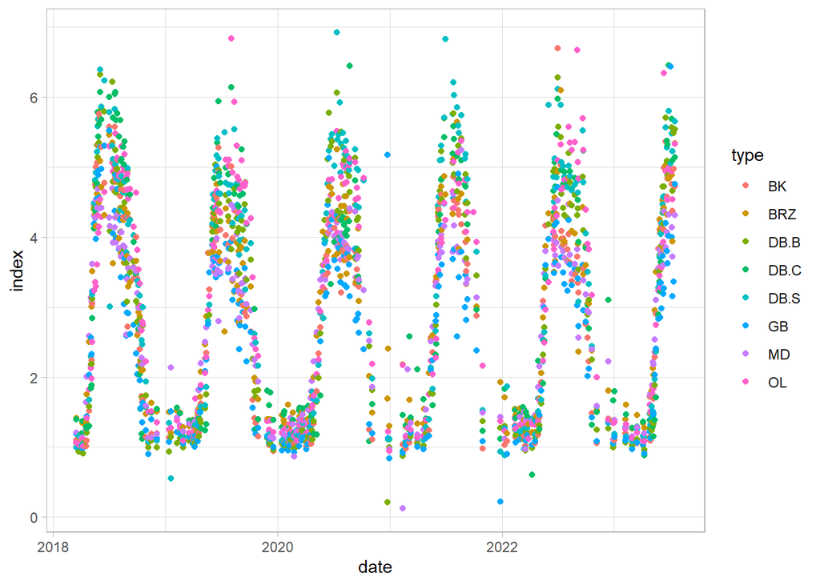

```r
df_clean = df %>%
  drop_na() %>%
  group_by(date, type) %>%
  summarise(index = mean(index)) %>%
  ungroup() %>%
  dplyr::filter(index < 7 & index > 0 & date > "2018-03-05")

ggplot(df_clean, aes(date, index, color = type))+
  geom_point()+
  theme_light()
```

### Example analysis on hornbeam (GB) time series

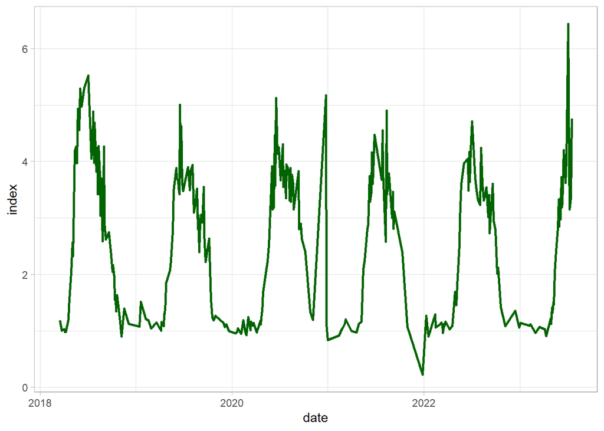

```r
df_gb = df_clean %>%
  dplyr::filter(type == "GB")
ggplot(df_gb, aes(date, index))+
  geom_line(color = "darkgreen", linewidth = 1)+
  theme_light()
```

Firstly, identify and replace outliers using simple linear interpolation:

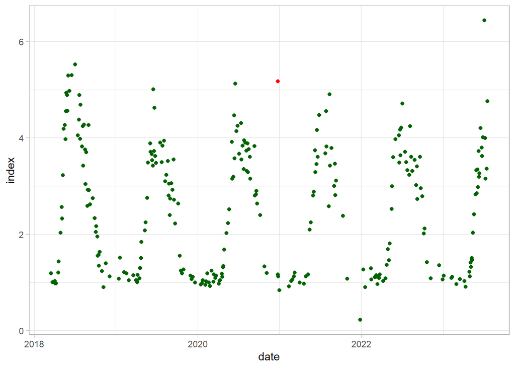

```r
df_gb$index_out = df_gb$index %>%
  tsclean()

ggplot(df_gb)+
  geom_point(aes(date, index), color = "red")+
  geom_point(aes(date, index_out), color = "darkgreen")+
  theme_light()
```

### Smoothing 1: Simple Moving Average

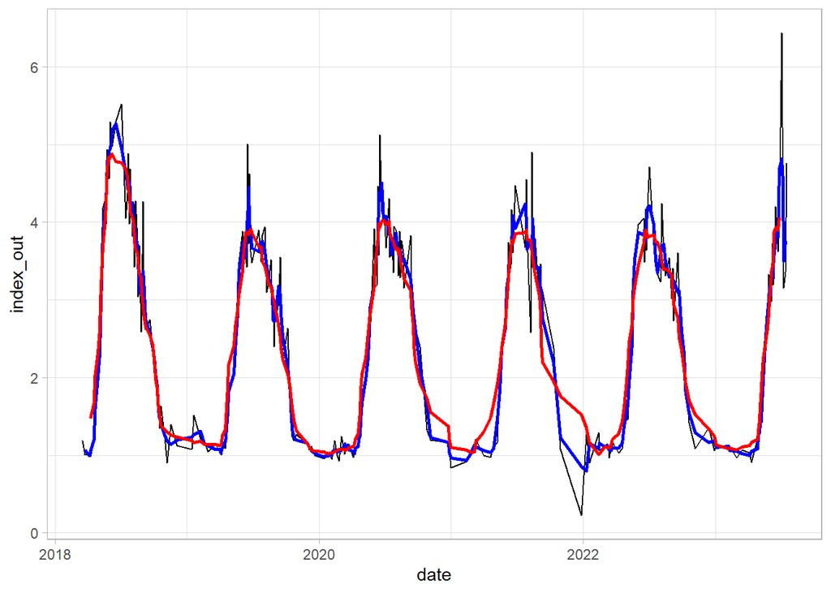

```r
df_gb$avg3 = rollmean(df_gb$index_out ,3, fill = NA)
df_gb$avg10 = rollmean(df_gb$index_out ,10, fill = NA)

ggplot(df_gb)+
  geom_line(aes(date, index_out))+
  geom_line(aes(date, avg3), color = "blue", linewidth = 1.0)+
  geom_line(aes(date, avg10), color = "red", linewidth = 1.0)+
  theme_light()
```

### Smoothing 2: Savitzky-Golay smoothing

We need to create regular (1-day) time series with NA for missing values. And then interpolate the unknown values using na.approx() from the zoo package:

```r
df_tsb = tsibble(df_gb[,c(1,4)], index = date, regular = TRUE) %>%
  fill_gaps() %>%
  mutate(approx = na.approx(index_out))
```

Apply Savitzky-Golay filter. n is a filter length (odd number) - test different values.

```r
df_tsb$sg = df_tsb$approx %>%
  sgolayfilt(n = 71)
```

Analyze the results on plot - line represent time series smoothed by S-G, red dots - original values and blue dots - interpolated values

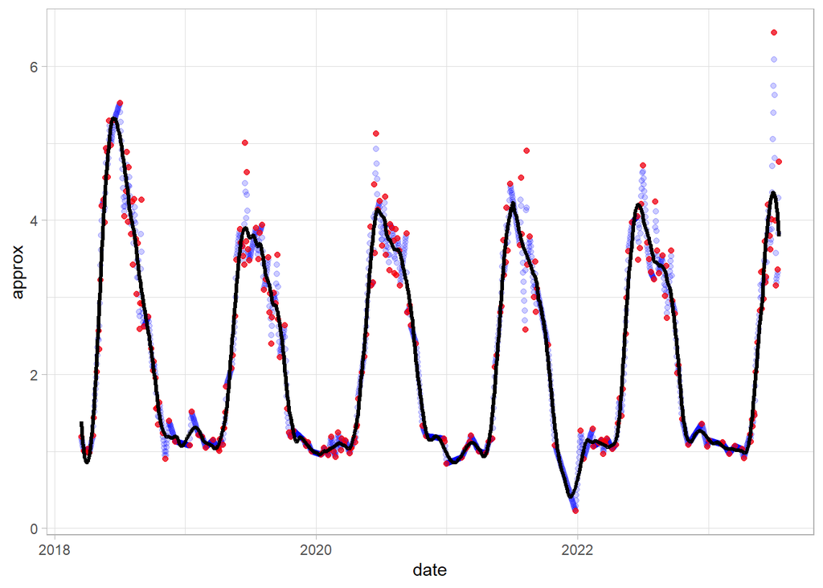

```r
ggplot(df_tsb)+
  geom_point(aes(date, approx), color = "blue", alpha = 0.2)+
  geom_point(aes(date, index_out), color = "red", alpha = 0.7)+
  geom_line(aes(date, sg), size = 1.1)+
  theme_light()
```

### Smoothing 3: Generalized Additive Models (GAM) fitting

The first step is the same as in Savitzky-Golay - we will create regular time series with NA values:

```r
df_tsb_gam = tsibble(df_gb[,c(1,4)], index = date, regular = TRUE) %>%
  fill_gaps() %>%
  ts() %>% #but here also we need to change date format from y-m-d to numeric (unix time)
  as.data.frame()
```

But now we can go straight to modelling without dealing with missing values!

GAM modelling with dates as predictor (Generalized Additive Mixed Models):

```r
model = gamm(df_tsb_gam$index_out ~ s(date, k = 60),
             data = df_tsb_gam , method = "REML")
```

Predicting values using GAM model and plotting the results:

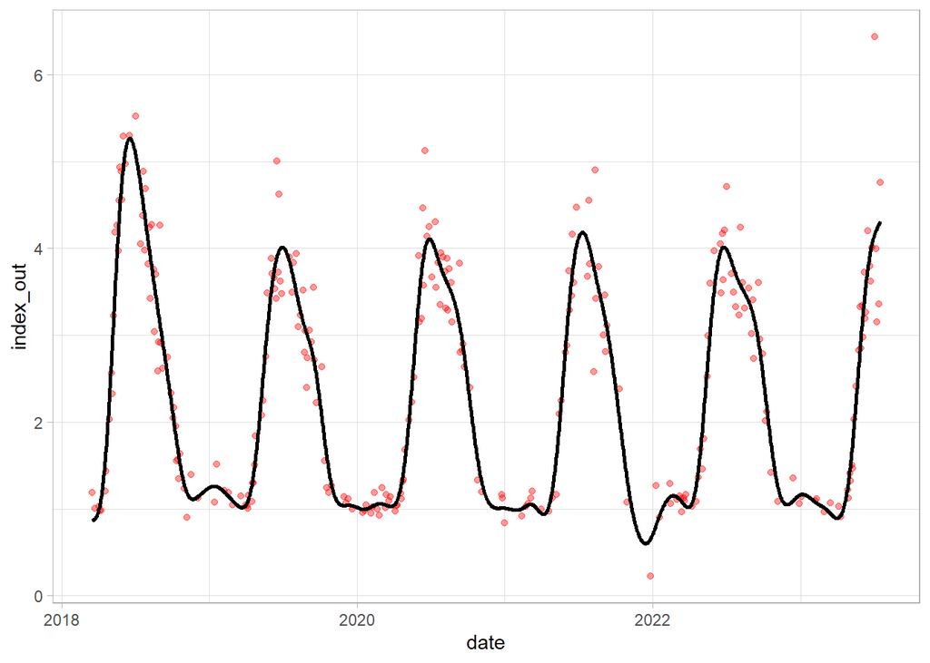

```r
df_tsb_gam$predicted = predict.gam(model$gam, df_tsb_gam)
df_tsb_gam$date = anydate(df_tsb_gam$date)

ggplot(df_tsb_gam)+
  geom_point(aes(date, index_out), color = "red", alpha = 0.4)+
  geom_line(aes(date, predicted), linewidth = 1)+
  theme_light()
```

Compare S-G (blue line) and GAM (black line):

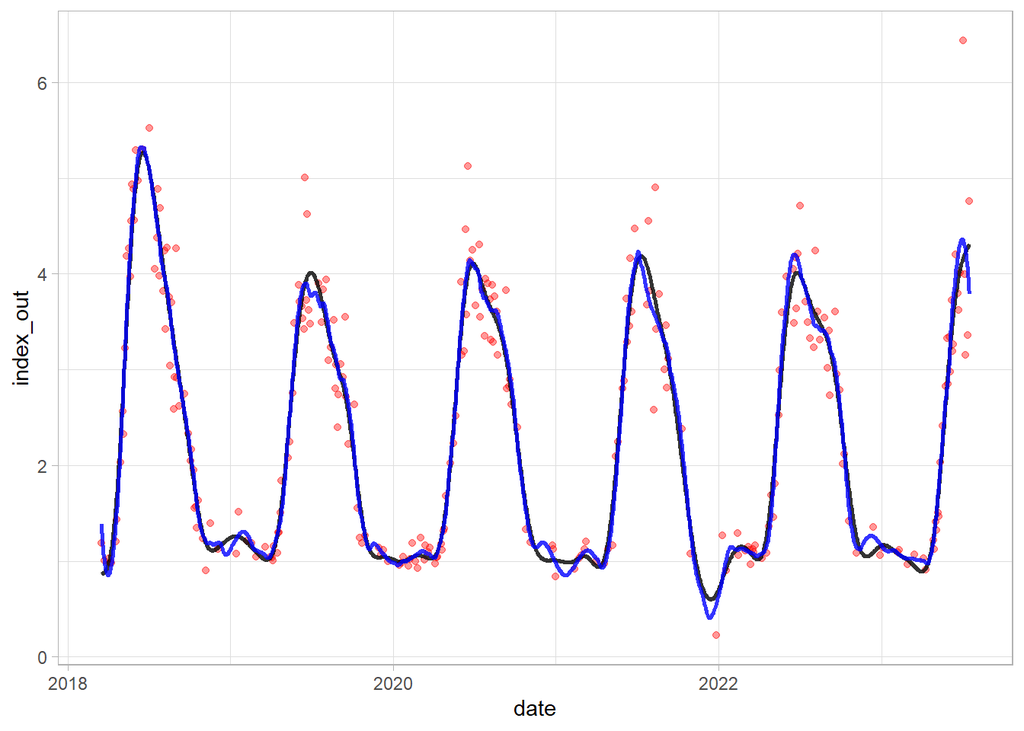

```r
df_tsb_gam$sg = df_tsb$sg

ggplot(df_tsb_gam)+
  geom_point(aes(date, index_out), color = "red", alpha = 0.4)+
  geom_line(aes(date, predicted), alpha = 0.8, linewidth = 1)+
  geom_line(aes(date, sg), color = "blue", alpha = 0.8, linewidth = 1)+
  theme_light()
```

**Excercise 1**

Read *landsat_ndvi_veg_2.csv* file and analyze the dataframe. Based on preliminary analysis, select one vegetation type, use cleaning/outlier removing if necessary, and perform one selected method smoothing/fitting. Finally, visualize the results and evaluate its performance! Pay attention to:

- correctly convert system.index variable to date format (use e.g. substr() function)
- defining correct min and max values
- pay attention to the date range
- when using moving average and SG - set appropriate window size (n)

## Part 2: Detecting trends and breaks

In this part we will use Savitzky-Golay smoothing and then try to detect breaks and trends in satellite time series for the part of Poznań

### Checking and smoothing selected pixels (samples)

Load the data (already pre-processed:)

```r
df = read.csv("d:/OGH2023_data/poznan_ndvi_clean.csv")
str(df)
```

```
## 'data.frame':    398387 obs. of  4 variables:
##  $ X           : int  1 2 3 4 5 6 7 8 9 10 ...
##  $ system.index: chr  "2018-04-06" "2018-04-06" "2018-04-06" "2018-04-06" ...
##  $ pointid     : int  1 2 3 4 5 6 7 8 9 10 ...
##  $ index       : num  0.395 0.365 0.427 0.405 0.454 ...
```

```r
summary(df)
```

```
##        X          system.index          pointid           index
##  Min.   :     1   Length:398387      Min.   :   1.0   Min.   :-0.2184
##  1st Qu.: 99598   Class :character   1st Qu.: 450.0   1st Qu.: 0.2277
##  Median :199194   Mode  :character   Median : 900.0   Median : 0.4004
##  Mean   :199194                      Mean   : 903.1   Mean   : 0.4344
##  3rd Qu.:298791                      3rd Qu.:1357.0   3rd Qu.: 0.6487
##  Max.   :398387                      Max.   :1813.0   Max.   : 0.9997
```

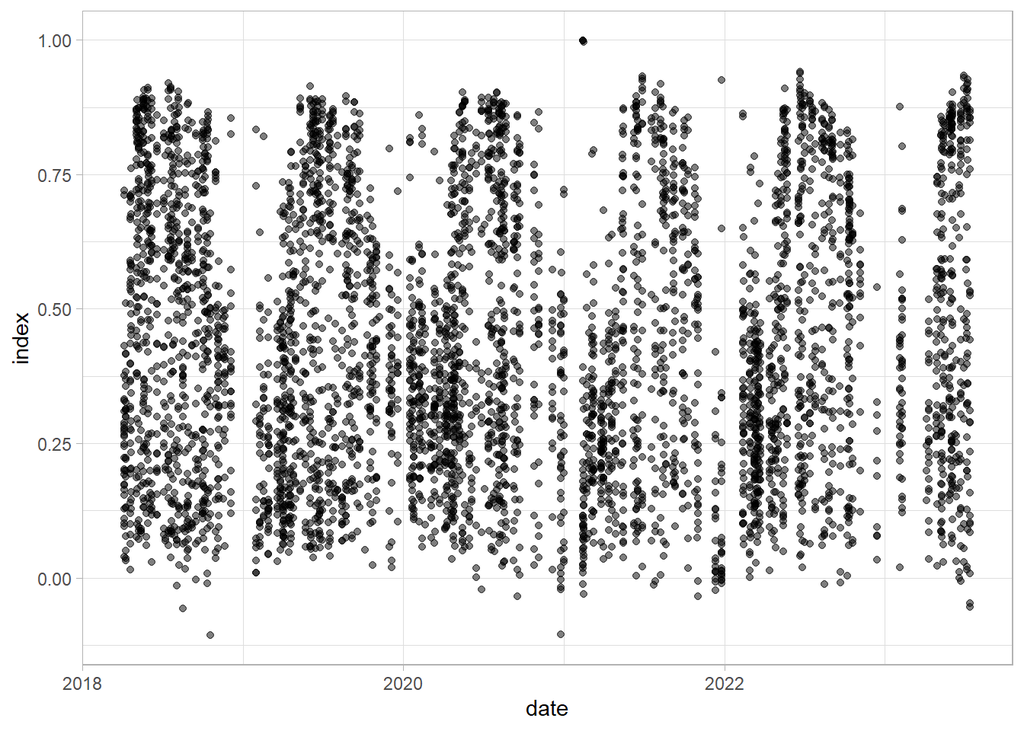

```r
df = df[,-1]
df$system.index = as.Date(df$system.index, format = "%Y-%m-%d")
names(df) = c("date", "pointid", "index")


ggplot(sample_n(df, 5000), aes(date, index))+
  geom_point(alpha = 0.5)+
  theme_light()
```

Check examples examples with pointid 551 - vegetation development; 1311 and 472 - new built-up; 1623 conifer trees; 1149 built up to green space

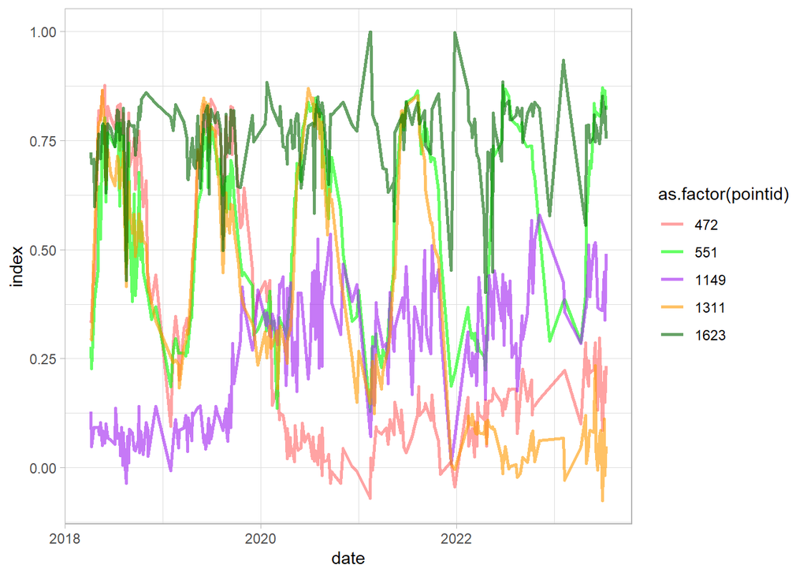

```r
df_sel = df %>%
  dplyr::filter(pointid %in% c(472, 551,1149,1311, 1623))

ggplot(df_sel, aes(date, index,
                   group = pointid, color = as.factor(pointid)))+
  geom_line(linewidth = 1, alpha = 0.6)+
  scale_color_manual(values = c("#FF6666", "green", "purple", "#FF9900", "darkgreen"))+
  theme_light()
```

Let’s now check the just the place with vegetation development and than smooth the time series:

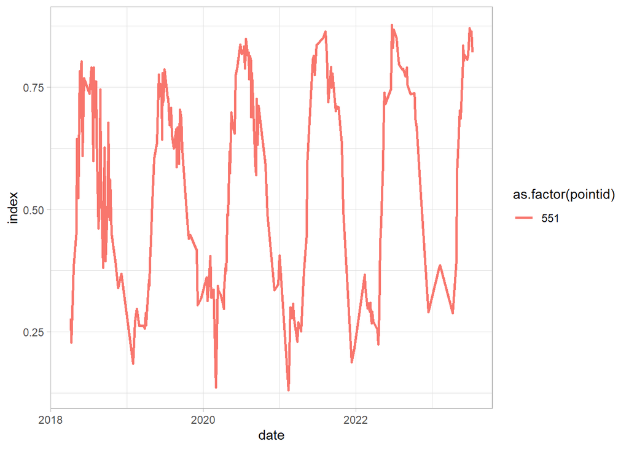

```r
df_sel = df %>%
  dplyr::filter(pointid %in% c(551))
ggplot(df_sel, aes(date, index,
                   group = pointid, color = as.factor(pointid)))+
  geom_line(linewidth = 1)+
  theme_light()
```

Based on previous part, we will use Savitzky-Golay smoothing - to make it easier you can find the function with all necessary steps (e.g. producing regular time series) and applying S-G function. The input for this is id (pointid in our loaded dataframe) and input_df, with 3 variables: date, id, and index value.

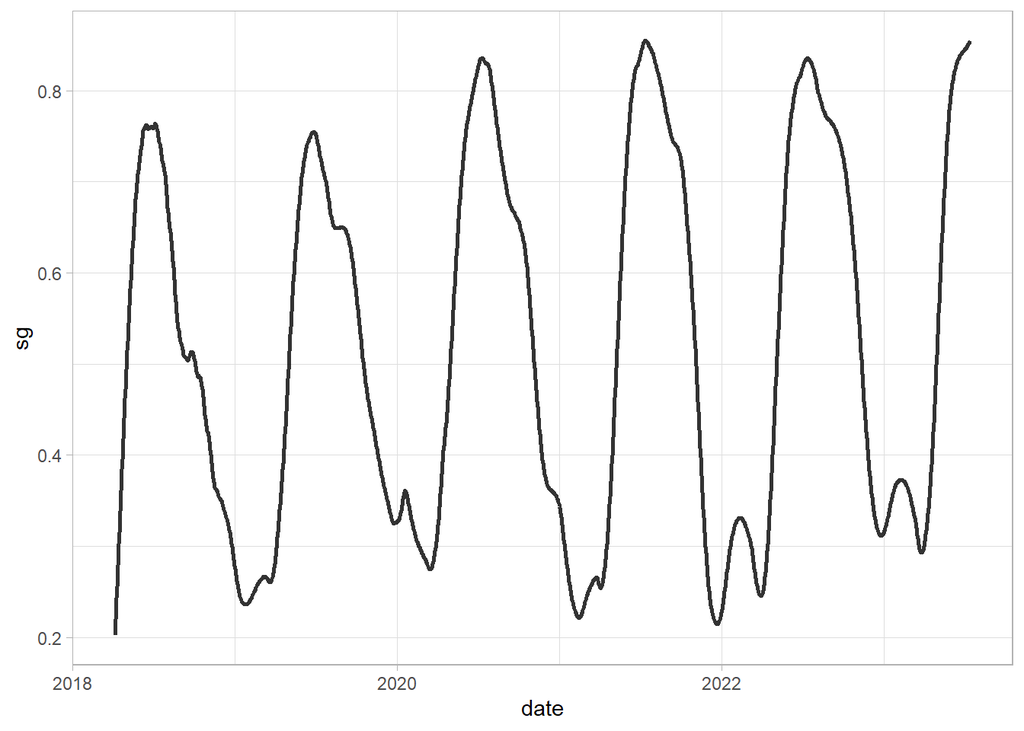

```r
sg = function(id, input_df) {
  df_sel = input_df %>%
    dplyr::filter(pointid == id)
  df_tsb = tsibble(df_sel[,c(1,3)], index = date, regular = TRUE) %>%
    fill_gaps() %>%
    mutate(approx = na.approx(index))
  df_tsb$sg = df_tsb$approx %>%
    sgolayfilt(n = 91)
  df_tsb$id = id
  return(df_tsb[,-2])
}


sg(551, df) %>%
  ggplot()+
  geom_line(aes(date, sg),
            alpha = 0.8, linewidth = 1)+
  theme_light()
```

### Time series decomposition

First example - vegetation development again:

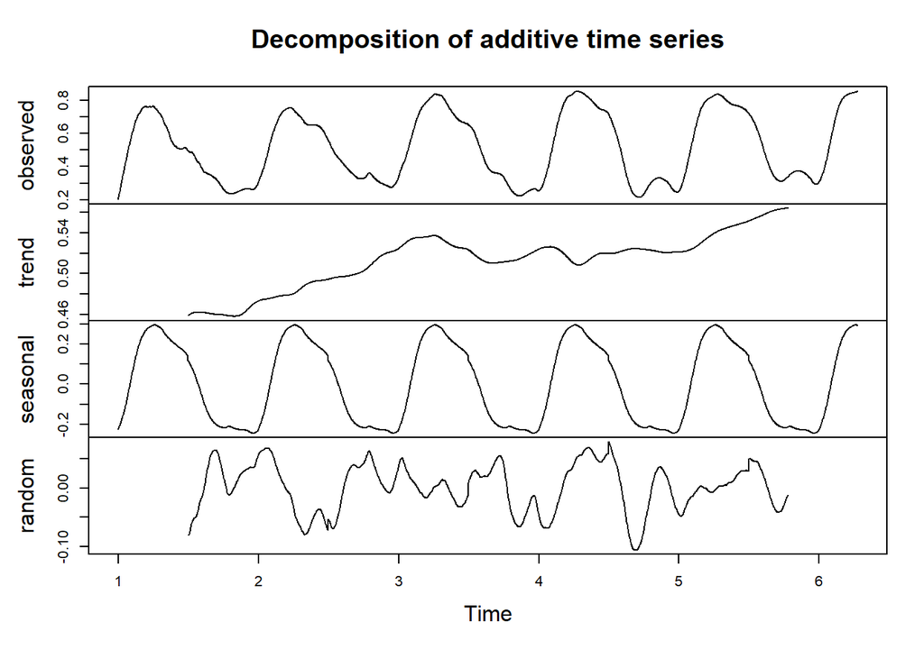

```r
df_sg = sg(551, df)

df_sg_ts = df_sg[,c(1,3)] %>%
  ts(frequency = 365)

df_sg_ts[,2] %>% decompose() %>%
  plot()
```

Second example - new built up area in the vegetated land:

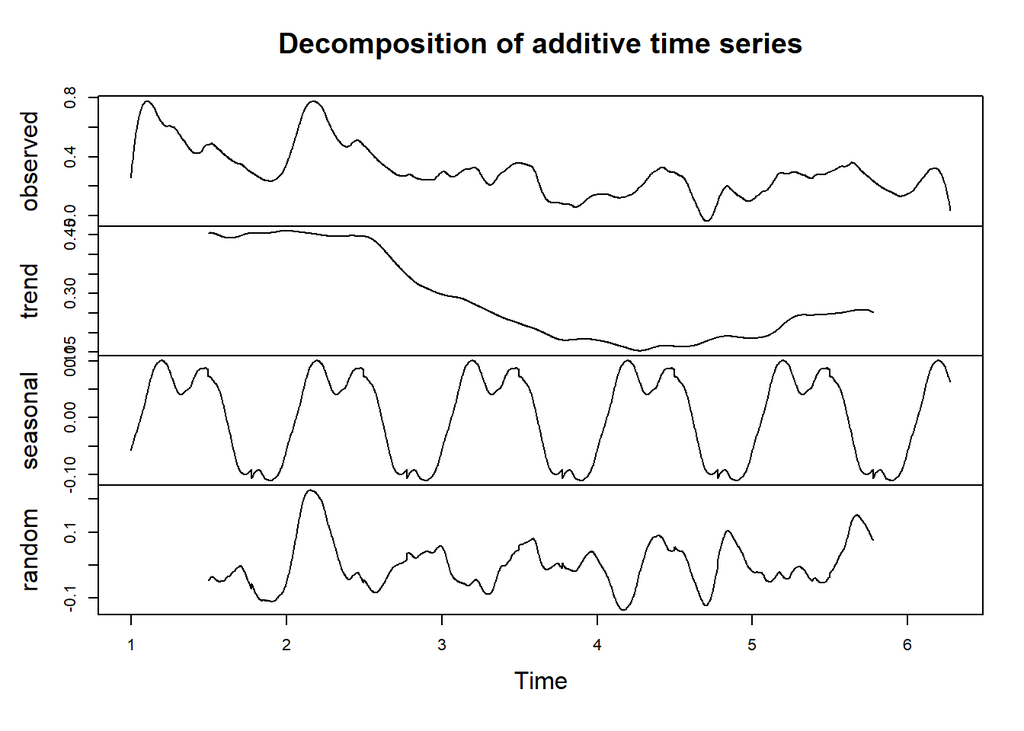

```r
df_sg = sg(1068, df)

df_sg_ts = df_sg[,c(1,3)] %>%
  ts(frequency = 365)

df_sg_ts[,2] %>% decompose() %>%
  plot()
```

Different method - stl: Seasonal Decomposition of Time Series by Loess:

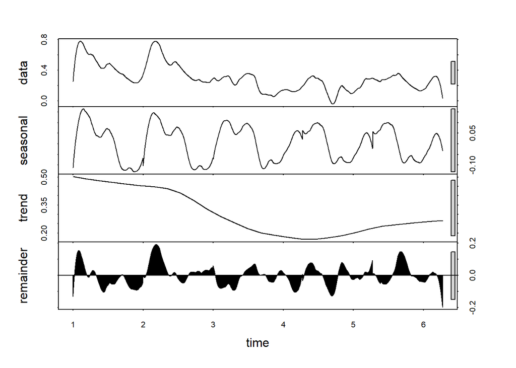

```r
df_sg_ts[,2] %>%
  stl(s.window = 7) %>%
  plot()
```

### Detecting breaks

Detect breaks using bfast function - firstly, apply S-G smoothing (the data should be a regular ts() object without NAs). This is the example for pixel no 1311.

```r
change1 = sg(1311, df) %>%
  select(date, sg) %>%
  ts(frequency = 365)
```

Use bfast function - which is an iterative break detection in seasonal and trend component of a time series; plot the results and the detected break date:

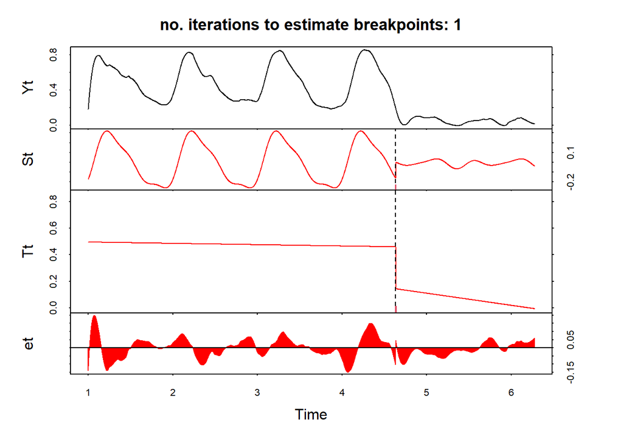

```r
fit = bfast(change1[,2], season = "harmonic", max.iter = 1, breaks = 1)
plot(fit)
```

```r
anydate(change1[1] + fit$Time)
```

```
## [1] "2021-11-23"
```

And another example

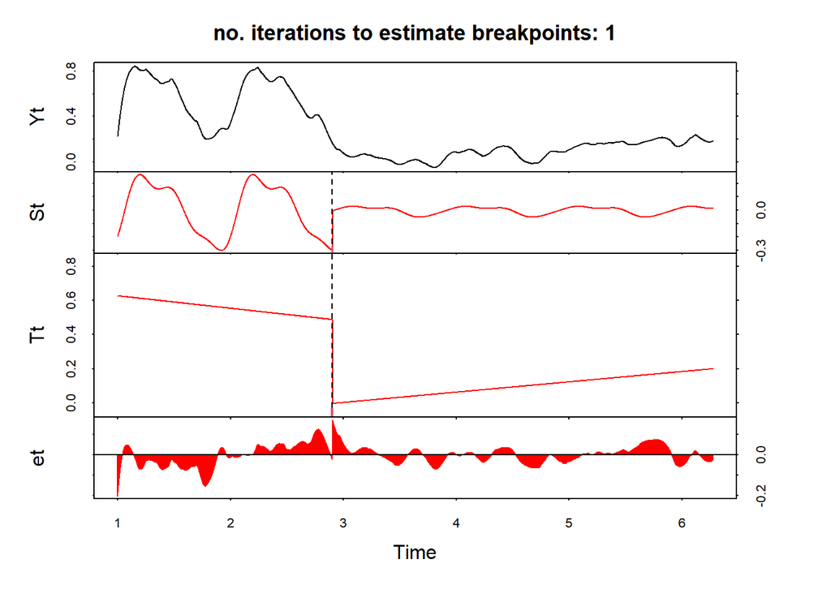

```r
change1 = sg(472, df) %>%
  select(date, sg) %>%
  ts(frequency = 365)
fit = bfast(change1[,2], season = "harmonic", max.iter = 1, breaks = 1)
plot(fit)
```

```r
anydate(change1[1] + fit$Time)
```

```
## [1] "2020-03-01"
```

Another useful function is bfast01 which checks for one major break in the time series

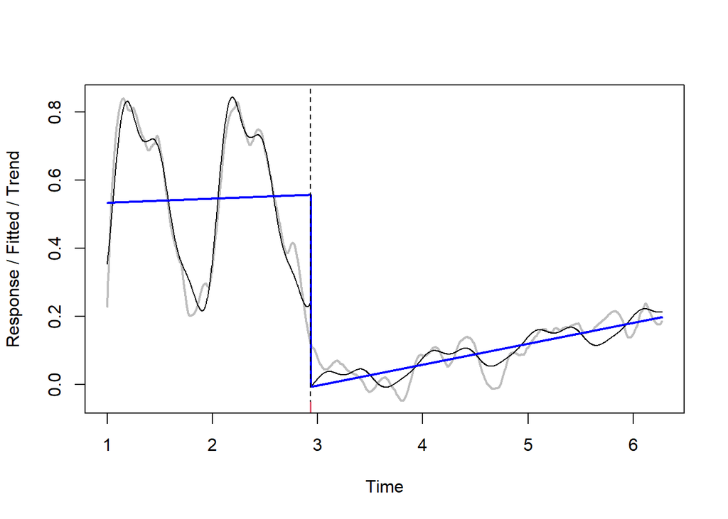

```r
fit = bfast01(change1[,2])
plot(fit)
```

Then these results can be, for example, joined with spatial data - and we can produce map of new built-up areas, like in the example below.

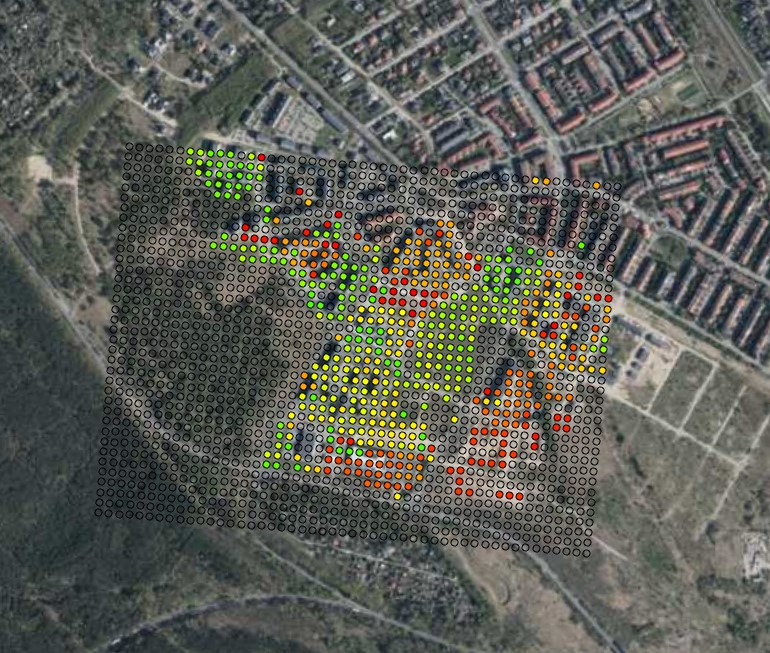

Still, method is not perfect, you can try testing other parameters! :)

**Excercise 2**

Use *landsat_ndvi_veg_2.csv* dataframe again and decompose the time series for selected vegetation type!